# Causal transformer model using position encodings

**Bruno Guratti** - **500225019**

```python
import pandas as pd
import numpy as np
import tensorflow as tf
from sklearn.model_selection import train_test_split
from tensorflow.keras.preprocessing.text import Tokenizer
from tensorflow.keras.preprocessing.sequence import pad_sequences
from sklearn.metrics import confusion_matrix, ConfusionMatrixDisplay, roc_curve, auc
from sklearn.preprocessing import label_binarize
import matplotlib.pyplot as plt
```

```
2024-07-05 11:19:54.462262: E external/local_xla/xla/stream_executor/cuda/cuda_dnn.cc:9261] Unable to register cuDNN factory: Attempting to register factory for plugin cuDNN when one has already been registered
2024-07-05 11:19:54.462364: E external/local_xla/xla/stream_executor/cuda/cuda_fft.cc:607] Unable to register cuFFT factory: Attempting to register factory for plugin cuFFT when one has already been registered
2024-07-05 11:19:54.601242: E external/local_xla/xla/stream_executor/cuda/cuda_blas.cc:1515] Unable to register cuBLAS factory: Attempting to register factory for plugin cuBLAS when one has already been registered
```

```python
# Replace 'dataset.csv' with the path to your dataset
df = pd.read_csv('/kaggle/input/sentiment-data/Sentiment_Data/Sentiment_Data.csv', encoding='ISO-8859-1')
pd.set_option('display.max_colwidth', 100)
df.head()
```

|  | Tweet | Sentiment |
| --- | --- | --- |
| 0 | @_angelica_toy Happy Anniversary!!!....The Day the FreeDUMB Died (In the tune of Don McLean's "A... | Mild_Pos |
| 1 | @McfarlaneGlenda Happy Anniversary!!!....The Day the FreeDUMB Died (In the tune of Don McLean's ... | Mild_Pos |
| 2 | @thevivafrei @JustinTrudeau Happy Anniversary!!!....The Day the FreeDUMB Died (In the tune of Do... | Mild_Pos |
| 3 | @NChartierET Happy Anniversary!!!....The Day the FreeDUMB Died (In the tune of Don McLean's "Ame... | Mild_Pos |
| 4 | @tabithapeters05 Happy Anniversary!!!....The Day the FreeDUMB Died (In the tune of Don McLean's ... | Mild_Pos |

## Preprocessing data

```python
# Mapping dictionary
sentiment_map = {
    'Mild_Pos': 'Positive',
    'Strong_Pos': 'Positive',
    'Neutral': 'Neutral',
    'Strong_Neg': 'Negative',
    'Mild_Neg': 'Negative'
}

# Applying the mapping
df['Sentiment'] = df['Sentiment'].map(sentiment_map)

# Getting unique values
unique_values = df['Sentiment'].unique()
unique_values
```

```
array(['Positive', 'Neutral', 'Negative'], dtype=object)
```

```python
slang = pd.read_csv('/kaggle/input/sentiment-data/Sentiment_Data/slangs.csv')
slang_map = dict(zip(slang['slang'], slang['meaning']))

def replace_slangs(text):
    if isinstance(text, str):
            for word in text.split():
                if word in slang_map:
                    text = text.replace(word, slang_map[word])
    return text

def replace_emoticons(text):
    emoticon = pd.read_csv('/kaggle/input/sentiment-data/emoticons.csv')
    emoticon_map = dict(zip(emoticon['emoticon'], emoticon['meaning']))
    for emot in emoticon_map:
        text = text.replace(emot, ' ' + emoticon_map[emot] + ' ')
    return text

def handle_negations(text):
    negation_patterns = ["n't", "not", "never", "no"]
    words = text.split()
    for i in range(len(words)):
        if words[i].lower() in negation_patterns:
            if i+1 < len(words):
                words[i+1] = "NOT_" + words[i+1] + " "
    return ' '.join(words)

# Function to clean text
def clean_text(text):
    if isinstance(text, str):
        text = re.sub(r'@\w+', ' ', text)              # Remove mentions
        text = re.sub(r'#', ' ', text)                 # Remove hashtags
        text = re.sub(r'\w+:\/\/\S+', ' ', text)           # Remove hyperlinks
        text = re.sub(r'\S*@\S*\s?', ' ', text)        # Remove email addresses
        text = re.sub(r'[^\w\s]', ' ', text)           # Remove punctuation
        text = re.sub(r'[^a-zA-Z]+', ' ', text)           # Remove all non-English characters
        text = handle_negations(text)                  # Handle negations
        text = replace_emoticons(text)                 # Replace emoticons by their meanings
        text = emoji.demojize(text)                     # Replace emojis by their meanings
        text = replace_slangs(text)                    # Replace slangs by their meanings
        text = re.sub(r'\d+', ' ', text)             # Remove numbers
        text = text.lower()                            # Convert to lowercase

    return text
```

```python
df['cleaned_Tweet'] = df['Tweet'].apply(clean_text)
```

```python
df.to_csv('/kaggle/working/cleaned_tweets.csv', index=False)
```

## Load the cleaned dataset

```python
# Load the dataset
df = pd.read_csv('/kaggle/input/cleaned-sentimento/cleaned_tweets.csv')

# Sample dataset to get the exact same amount of data from each class
df = df.groupby('Sentiment').apply(lambda x: x.sample(n=76612, replace=True))

# Select relevant columns
texts = df['cleaned_Tweet'].astype(str).values  # Convert all texts to strings
labels = df['Sentiment'].values

# Fill any missing values in texts with an empty string
texts = np.where(pd.isna(texts), '', texts)

# Map string labels to integers
label_mapping = {'Negative': 0, 'Neutral': 1, 'Positive': 2}
labels = np.array([label_mapping[label] for label in labels])

# Split the data into training and testing sets
X_train, X_test, y_train, y_test = train_test_split(texts, labels, test_size=0.2, random_state=42)
```

```python
import os
import nltk
nltk_data_dir = os.path.expanduser('/kaggle/working/nltk_data')
if not os.path.exists(nltk_data_dir):
    os.makedirs(nltk_data_dir)

nltk.data.path.append(nltk_data_dir)
nltk.download('wordnet', download_dir=nltk_data_dir)
nltk.download('stopwords', download_dir=nltk_data_dir)
nltk.download('punkt', download_dir=nltk_data_dir)
!unzip /kaggle/working/nltk_data/corpora/wordnet.zip -d /kaggle/working/nltk_data/corpora/
```

```python
import pandas as pd
import numpy as np
import nltk
from nltk.corpus import wordnet
from nltk.tokenize import word_tokenize
from nltk.corpus import stopwords
from nltk.stem import WordNetLemmatizer
from tensorflow.keras.preprocessing.text import Tokenizer
from tensorflow.keras.preprocessing.sequence import pad_sequences
from tensorflow.keras.preprocessing.text import Tokenizer
from sklearn.model_selection import train_test_split
import os

# Define some parameters
max_vocab_size = 5000
max_seq_length = 30

# Initialize the lemmatizer and stopwords
lemmatizer = WordNetLemmatizer()
stop_words = set(stopwords.words('english'))
tokenizer = Tokenizer(num_words=max_vocab_size)

# Your existing preprocess_text function
def preprocess_text(tweet):
    tokens = word_tokenize(tweet)  # Tokenize
    tokens = [word for word in tokens if word.lower() not in stop_words]  # Remove stopwords
    tokens = [lemmatizer.lemmatize(word) for word in tokens]  # Lemmatize
    tweet = ' '.join(tokens)
    return tweet

# Preprocess the texts
X_train = [preprocess_text(tweet) for tweet in X_train]
X_test = [preprocess_text(tweet) for tweet in X_test]

# Initialize the tokenizer
tokenizer = Tokenizer()
tokenizer.fit_on_texts(X_train)

# Convert texts to sequences
X_train_seq = tokenizer.texts_to_sequences(X_train)
X_test_seq = tokenizer.texts_to_sequences(X_test)

# Pad sequences to ensure uniform input size
X_train_pad = pad_sequences(X_train_seq, maxlen=max_seq_length)
X_test_pad = pad_sequences(X_test_seq, maxlen=max_seq_length)
```

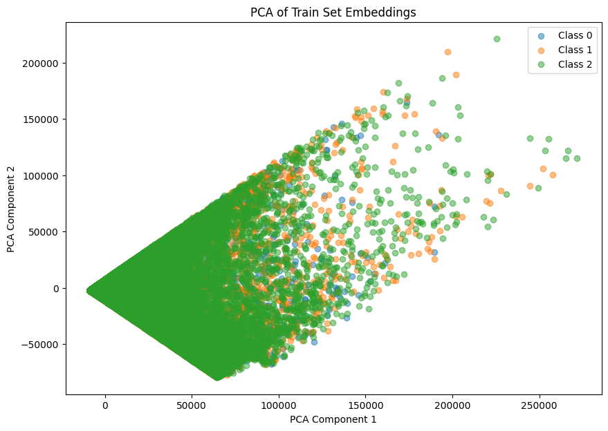

```python
from sklearn.decomposition import PCA
import matplotlib.pyplot as plt

# Apply PCA to the padded sequences
pca = PCA(n_components=2)
X_train_pca = pca.fit_transform(X_train_pad)

# Plot the PCA embeddings
def plot_pca_embeddings(embeddings, labels, title):
    plt.figure(figsize=(10, 7))
    for i in np.unique(labels):
        idxs = np.where(labels == i)
        plt.scatter(embeddings[idxs, 0], embeddings[idxs, 1], label=f'Class {i}', alpha=0.5)
    plt.xlabel('PCA Component 1')
    plt.ylabel('PCA Component 2')
    plt.title(title)
    plt.legend()
    plt.show()

# Plot train embeddings
plot_pca_embeddings(X_train_pca, np.array(y_train), 'PCA of Train Set Embeddings')
```

```python
class PositionalEncoding(tf.keras.layers.Layer):
    def __init__(self, d_model, max_len):
        super(PositionalEncoding, self).__init__()
        self.pos_encoding = self.positional_encoding(max_len, d_model)

    def positional_encoding(self, position, d_model):
        angle_rads = self.get_angles(np.arange(position)[:, np.newaxis],
                                     np.arange(d_model)[np.newaxis, :],
                                     d_model)
        angle_rads[:, 0::2] = np.sin(angle_rads[:, 0::2])
        angle_rads[:, 1::2] = np.cos(angle_rads[:, 1::2])
        pos_encoding = angle_rads[np.newaxis, ...]
        return tf.cast(pos_encoding, dtype=tf.float32)

    def get_angles(self, pos, i, d_model):
        angle_rates = 1 / np.power(10000, (2 * (i//2)) / np.float32(d_model))
        return pos * angle_rates

    def call(self, inputs):
        return inputs + self.pos_encoding[:, :tf.shape(inputs)[1], :]

def transformer_model(vocab_size, d_model, num_heads, ff_dim, num_layers, max_seq_length, l2_reg=0.01, dropout_rate=0.1):
    initializer = tf.keras.initializers.GlorotUniform()

    inputs = tf.keras.Input(shape=(max_seq_length,))
    embedding_layer = tf.keras.layers.Embedding(vocab_size, d_model)(inputs)
    pos_encoding_layer = PositionalEncoding(d_model, max_seq_length)(embedding_layer)

    for _ in range(num_layers):
        attn_output = tf.keras.layers.MultiHeadAttention(num_heads=num_heads, key_dim=d_model)(pos_encoding_layer, pos_encoding_layer)
        attn_output = tf.keras.layers.Dropout(dropout_rate)(attn_output)
        out1 = tf.keras.layers.LayerNormalization(epsilon=1e-6)(pos_encoding_layer + attn_output)

        ffn_output = tf.keras.layers.Dense(ff_dim, activation='relu', kernel_initializer=initializer,
                                           kernel_regularizer=tf.keras.regularizers.l2(l2_reg))(out1)
        ffn_output = tf.keras.layers.Dense(d_model, kernel_initializer=initializer,
                                           kernel_regularizer=tf.keras.regularizers.l2(l2_reg))(ffn_output)
        ffn_output = tf.keras.layers.Dropout(dropout_rate)(ffn_output)
        pos_encoding_layer  = tf.keras.layers.LayerNormalization(epsilon=1e-6)(out1 + ffn_output)

    outputs = tf.keras.layers.GlobalAveragePooling1D()(pos_encoding_layer)
    outputs = tf.keras.layers.Dropout(dropout_rate)(outputs)
    outputs = tf.keras.layers.Dense(20, activation='relu', kernel_initializer=initializer,
                                    kernel_regularizer=tf.keras.regularizers.l2(l2_reg))(outputs)
    outputs = tf.keras.layers.Dense(3, activation='softmax', kernel_initializer=initializer,
                                    kernel_regularizer=tf.keras.regularizers.l2(l2_reg))(outputs)

    return tf.keras.Model(inputs=inputs, outputs=outputs)
```

```python
from sklearn.metrics import confusion_matrix, ConfusionMatrixDisplay, roc_curve, auc, classification_report
from sklearn.preprocessing import label_binarize
import matplotlib.pyplot as plt
import numpy as np

def evaluate_model_performance(model, X_test_pad, y_test, history):
    """
    Evaluates the performance of a classification model by printing a classification report,
    plotting accuracy and loss curves, confusion matrix, and ROC AUC curves.

    Parameters:
    model: Trained model to evaluate
    X_test_pad: Padded test data features
    y_test: True labels for the test data
    history: Training history object containing accuracy and loss values

    Returns:
    None
    """
    # Predict on validation data
    y_test_pred = np.argmax(model.predict(X_test_pad), axis=-1)

    # Generate classification report
    print("Classification Report:")
    print(classification_report(y_test, y_test_pred, target_names=['Negative', 'Neutral', 'Positive']))

    # Plot training & validation accuracy values
    plt.figure(figsize=(12, 4))
    plt.subplot(1, 2, 1)
    plt.plot(history.history['accuracy'])
    plt.plot(history.history['val_accuracy'])
    plt.title('Model accuracy')
    plt.ylabel('Accuracy')
    plt.xlabel('Epoch')
    plt.legend(['Train', 'Validation'], loc='upper left')

    # Plot training & validation loss values
    plt.subplot(1, 2, 2)
    plt.plot(history.history['loss'])
    plt.plot(history.history['val_loss'])
    plt.title('Model loss')
    plt.ylabel('Loss')
    plt.xlabel('Epoch')
    plt.legend(['Train', 'Validation'], loc='upper left')

    plt.tight_layout()
    plt.show()

    # Predict labels for the test set
    y_pred = model.predict(X_test_pad)
    y_pred_classes = np.argmax(y_pred, axis=1)

    # Compute the confusion matrix
    cm = confusion_matrix(y_test, y_pred_classes)

    # Binarize the labels for ROC AUC
    y_test_binarized = label_binarize(y_test, classes=[0, 1, 2])
    y_pred_binarized = label_binarize(y_pred_classes, classes=[0, 1, 2])

    # Compute ROC curve and ROC area for each class
    fpr = dict()
    tpr = dict()
    roc_auc = dict()
    for i in range(3):
        fpr[i], tpr[i], _ = roc_curve(y_test_binarized[:, i], y_pred[:, i])
        roc_auc[i] = auc(fpr[i], tpr[i])

    # Plot confusion matrix and combined ROC AUC
    fig, axes = plt.subplots(1, 2, figsize=(18, 6))

    # Plot confusion matrix
    disp = ConfusionMatrixDisplay(confusion_matrix=cm, display_labels=['Negative', 'Neutral', 'Positive'])
    disp.plot(cmap=plt.cm.Blues, ax=axes[0])
    axes[0].set_title('Confusion Matrix')

    # Plot ROC AUC for each class in the same graph
    ax = axes[1]
    colors = ['blue', 'green', 'red']
    for i, color in zip(range(3), colors):
        ax.plot(fpr[i], tpr[i], color=color, lw=2, label='Class {0} (area = {1:0.2f})'.format(i, roc_auc[i]))
    ax.plot([0, 1], [0, 1], color='navy', lw=2, linestyle='--')
    ax.set_xlim([0.0, 1.0])
    ax.set_ylim([0.0, 1.05])
    ax.set_title('ROC AUC for All Classes')
    ax.set_xlabel('False Positive Rate')
    ax.set_ylabel('True Positive Rate')
    ax.legend(loc="lower right")

    plt.tight_layout()
    plt.show()
```

## Model 1

```python
# Define model parameters
vocab_size = max_vocab_size
d_model = 64
num_heads = 8
ff_dim = 32
num_layers = 1

# Create and compile the model
model = transformer_model(vocab_size, d_model, num_heads, ff_dim, num_layers, max_seq_length, dropout_rate=0.1)
model.compile(optimizer='adam', loss='sparse_categorical_crossentropy', metrics=['accuracy'])
model.summary()
```

```
Model: "functional_109"
```

[output not shown]

```
 Total params: 458,483 (1.75 MB)
```

```
 Trainable params: 458,483 (1.75 MB)
```

```
 Non-trainable params: 0 (0.00 B)
```

```python
import time

from sklearn.utils.class_weight import compute_class_weight
import numpy as np

# Assuming y_train contains the class labels
class_weights = compute_class_weight('balanced', classes=np.unique(y_train), y=y_train)
class_weights = {i : class_weights[i] for i in range(len(class_weights))}

# Early Stopping callback
early_stopping = tf.keras.callbacks.EarlyStopping(monitor='val_loss', patience=3, restore_best_weights=True)

# Train the model
start_time = time.time()
history = model.fit(X_train_pad,
                    y_train,
                    epochs=10,
                    batch_size=32,
                    validation_split=0.1,
                    callbacks=[early_stopping],
                    class_weight=class_weights)
elapsed_time = time.time() - start_time
print(f"Time taken for training: {elapsed_time:.2f} seconds")
```

```
5172/5172 ━━━━━━━━━━━━━━━━━━━━ 35s 5ms/step - accuracy: 0.5983 - loss: 1.2103 - val_accuracy: 0.7092 - val_loss: 0.6929
5172/5172 ━━━━━━━━━━━━━━━━━━━━ 18s 3ms/step - accuracy: 0.7361 - loss: 0.6454 - val_accuracy: 0.7349 - val_loss: 0.6428
5172/5172 ━━━━━━━━━━━━━━━━━━━━ 17s 3ms/step - accuracy: 0.7614 - loss: 0.5893 - val_accuracy: 0.7463 - val_loss: 0.6200
5172/5172 ━━━━━━━━━━━━━━━━━━━━ 18s 3ms/step - accuracy: 0.7774 - loss: 0.5527 - val_accuracy: 0.7525 - val_loss: 0.6169
5172/5172 ━━━━━━━━━━━━━━━━━━━━ 17s 3ms/step - accuracy: 0.7909 - loss: 0.5174 - val_accuracy: 0.7527 - val_loss: 0.6013
5172/5172 ━━━━━━━━━━━━━━━━━━━━ 17s 3ms/step - accuracy: 0.8047 - loss: 0.4921 - val_accuracy: 0.7501 - val_loss: 0.6046
5172/5172 ━━━━━━━━━━━━━━━━━━━━ 18s 3ms/step - accuracy: 0.8154 - loss: 0.4687 - val_accuracy: 0.7618 - val_loss: 0.6050
5172/5172 ━━━━━━━━━━━━━━━━━━━━ 18s 3ms/step - accuracy: 0.8265 - loss: 0.4456 - val_accuracy: 0.7601 - val_loss: 0.6075
Time taken for training: 158.40 seconds
```

```
1437/1437 ━━━━━━━━━━━━━━━━━━━━ 3s 2ms/step
Classification Report:
              precision    recall  f1-score   support

    Negative       0.78      0.76      0.77     15192
     Neutral       0.71      0.69      0.70     15187
    Positive       0.77      0.81      0.79     15589

    accuracy                           0.75     45968
   macro avg       0.75      0.75      0.75     45968
weighted avg       0.75      0.75      0.75     45968
```

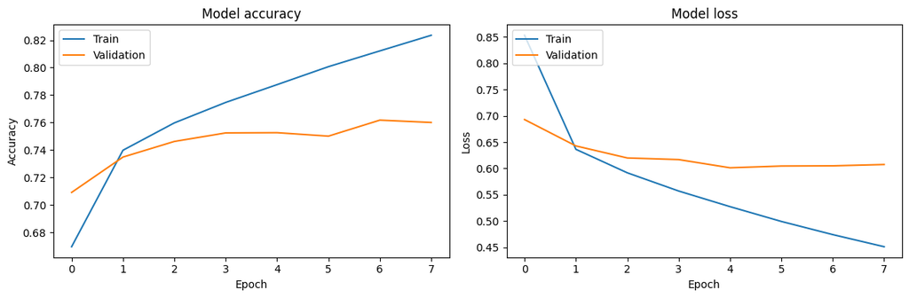

```
1437/1437 ━━━━━━━━━━━━━━━━━━━━ 2s 1ms/step
```

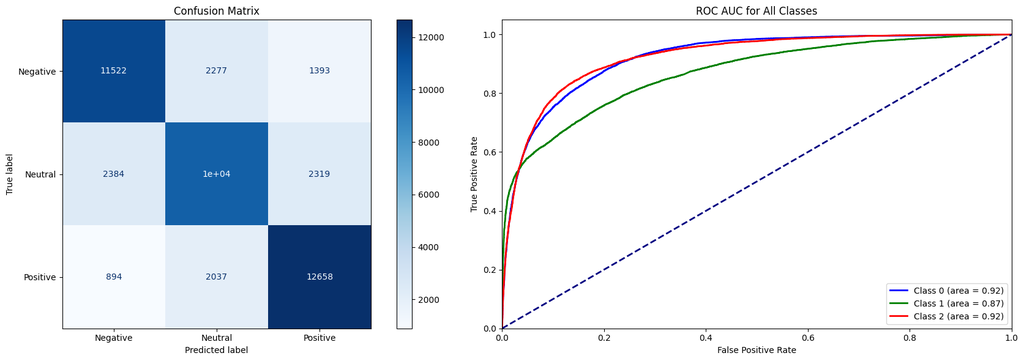

```python
evaluate_model_performance(model, X_test_pad, y_test, history)
```

### Comments

The model's performance is reasonably good, but there is noticeable overfitting. To improve it, we will add regularization and increase the dropout rate. In summary, the model achieves an overall accuracy of 75%. The precision, recall, and f1-score for each class indicate balanced performance across the different sentiment categories, with the "Positive" class showing the highest recall and f1-score. Further steps to reduce overfitting should help in enhancing the model's generalization capabilities.

## Model 2

```python
# Define model parameters
vocab_size = max_vocab_size
d_model = 64
num_heads = 32
ff_dim = 32
num_layers = 1

# Create and compile the model
model2 = transformer_model(vocab_size, d_model, num_heads, ff_dim, num_layers, max_seq_length, l2_reg=0.1, dropout_rate=0.5)
model2.compile(optimizer=Adam(learning_rate=1e-3),
              loss='sparse_categorical_crossentropy',
              metrics=['accuracy'])
model2.summary()
```

```
Model: "functional_161"
```

[output not shown]

```
 Total params: 856,307 (3.27 MB)
```

```
 Trainable params: 856,307 (3.27 MB)
```

```
 Non-trainable params: 0 (0.00 B)
```

```python
from tensorflow.keras.callbacks import ReduceLROnPlateau

reduce_lr = ReduceLROnPlateau(monitor='val_loss', factor=0.1, patience=3, min_lr=1e-6, verbose=1)

early_stopping = tf.keras.callbacks.EarlyStopping(monitor='val_loss', patience=5, restore_best_weights=True)

# Train the model
start_time = time.time()
history = model2.fit(X_train_pad,
                    y_train,
                    epochs=20,
                    batch_size=32,
                    validation_split=0.1,
                    callbacks=[early_stopping, reduce_lr],
                    class_weight=class_weights,
                    )
elapsed_time = time.time() - start_time
print(f"Time taken for training: {elapsed_time:.2f} seconds")
```

```
  33/5172 ━━━━━━━━━━━━━━━━━━━━ 25s 5ms/step - accuracy: 0.3388 - loss: 11.9667
```

```
W0000 00:00:1720201542.525968     151 graph_launch.cc:671] Fallback to op-by-op mode because memset node breaks graph update
```

```
5172/5172 ━━━━━━━━━━━━━━━━━━━━ 40s 6ms/step - accuracy: 0.4703 - loss: 1.9123 - val_accuracy: 0.6842 - val_loss: 0.7891 - learning_rate: 0.0010
5172/5172 ━━━━━━━━━━━━━━━━━━━━ 25s 5ms/step - accuracy: 0.7144 - loss: 0.7576 - val_accuracy: 0.7302 - val_loss: 0.7172 - learning_rate: 0.0010
5172/5172 ━━━━━━━━━━━━━━━━━━━━ 41s 5ms/step - accuracy: 0.7503 - loss: 0.6764 - val_accuracy: 0.7404 - val_loss: 0.6966 - learning_rate: 0.0010
5172/5172 ━━━━━━━━━━━━━━━━━━━━ 25s 5ms/step - accuracy: 0.7730 - loss: 0.6270 - val_accuracy: 0.7511 - val_loss: 0.6714 - learning_rate: 0.0010
5172/5172 ━━━━━━━━━━━━━━━━━━━━ 25s 5ms/step - accuracy: 0.7927 - loss: 0.5867 - val_accuracy: 0.7557 - val_loss: 0.6850 - learning_rate: 0.0010
5172/5172 ━━━━━━━━━━━━━━━━━━━━ 25s 5ms/step - accuracy: 0.8074 - loss: 0.5518 - val_accuracy: 0.7629 - val_loss: 0.6629 - learning_rate: 0.0010
5172/5172 ━━━━━━━━━━━━━━━━━━━━ 25s 5ms/step - accuracy: 0.8234 - loss: 0.5184 - val_accuracy: 0.7629 - val_loss: 0.6863 - learning_rate: 0.0010
5172/5172 ━━━━━━━━━━━━━━━━━━━━ 25s 5ms/step - accuracy: 0.8353 - loss: 0.4902 - val_accuracy: 0.7713 - val_loss: 0.6905 - learning_rate: 0.0010
5166/5172 ━━━━━━━━━━━━━━━━━━━━ 0s 5ms/step - accuracy: 0.8442 - loss: 0.4676
Epoch 9: ReduceLROnPlateau reducing learning rate to 0.00010000000474974513.
5172/5172 ━━━━━━━━━━━━━━━━━━━━ 25s 5ms/step - accuracy: 0.8442 - loss: 0.4676 - val_accuracy: 0.7702 - val_loss: 0.6891 - learning_rate: 0.0010
5172/5172 ━━━━━━━━━━━━━━━━━━━━ 25s 5ms/step - accuracy: 0.8659 - loss: 0.4172 - val_accuracy: 0.7786 - val_loss: 0.7114 - learning_rate: 1.0000e-04
5172/5172 ━━━━━━━━━━━━━━━━━━━━ 25s 5ms/step - accuracy: 0.8744 - loss: 0.3969 - val_accuracy: 0.7817 - val_loss: 0.7051 - learning_rate: 1.0000e-04
Time taken for training: 306.43 seconds
```

[output not shown]

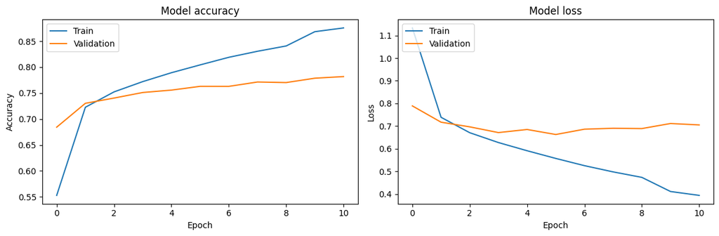

```
1437/1437 ━━━━━━━━━━━━━━━━━━━━ 2s 1ms/step
```

[figure not shown]

```python
evaluate_model_performance(model, X_test_pad, y_test, history)
```

### Model interpretability

```python
import lime
import lime.lime_text

# Function to preprocess and pad sequences for the model
def predict_fn(texts):
    # Preprocess the texts
    sequences = tokenizer.texts_to_sequences(texts)
    padded_sequences = pad_sequences(sequences, maxlen=max_seq_length)
    # Get model predictions
    return model.predict(padded_sequences)

# Apply LIME
explainer = lime.lime_text.LimeTextExplainer(class_names=['Negative', 'Neutral', 'Positive'])

# Select an instance to explain
i = 5000
explanation = explainer.explain_instance(X_test_texts[i], predict_fn, num_features=10)

# Show explanation
explanation.show_in_notebook(text=True)
```

[output not shown]

```
157/157 ━━━━━━━━━━━━━━━━━━━━ 0s 1ms/step
```

```python
from collections import defaultdict, Counter
import numpy as np

# Function to preprocess and pad sequences for the model
def predict_fn(texts):
    sequences = tokenizer.texts_to_sequences(texts)
    padded_sequences = pad_sequences(sequences, maxlen=max_seq_length)
    return model.predict(padded_sequences)

# Apply LIME
explainer = lime.lime_text.LimeTextExplainer(class_names=['Negative', 'Neutral', 'Positive'])

# Initialize dictionaries to store feature weights for each class
feature_weights = {'Negative': defaultdict(float), 'Neutral': defaultdict(float), 'Positive': defaultdict(float)}

# Number of samples to explain
num_samples = 1000
sample_indices = np.random.choice(len(X_test_texts), num_samples, replace=False)

# Loop through each sample and get LIME explanations
for i in sample_indices:
    explanation = explainer.explain_instance(X_test_texts[i], predict_fn, num_features=10)
    explanation_map = explanation.as_list()

    # Get the predicted class
    predicted_class = np.argmax(predict_fn([X_test_texts[i]])[0])
    class_name = ['Negative', 'Neutral', 'Positive'][predicted_class]

    # Aggregate feature weights for the predicted class
    for feature, weight in explanation_map:
        feature_weights[class_name][feature] += weight
```

```python
# Summarize the results to find the most influential words for each class
for class_name, weights in feature_weights.items():
    print(f"Top features for class {class_name}:")
    for feature, weight in Counter(weights).most_common(10):
        print(f"{feature}: {weight:.4f}")
    print("\n")
```

```
Top features for class Negative:
freedom: 12.6717
act: 0.9816
never: 0.7960
peaceful: 0.5439
chaos: 0.4076
demonstration: 0.4032
want: 0.3970
store: 0.3821
grant: 0.3336
insurrection: 0.3108


Top features for class Neutral:
freedomconvoy: 6.8982
chaos: 1.4879
declares: 1.3697
never: 1.1475
violating: 1.0305
haul: 0.9002
war: 0.8268
act: 0.7428
libel: 0.7234
fantasy: 0.7019


Top features for class Positive:
freedomconvoy: 2.5567
not: 2.0008
never: 0.4805
line: 0.4313
ban: 0.3812
photographer: 0.3712
hostage: 0.3683
founded: 0.3556
pro: 0.2839
racism: 0.2786
```

### Comments

The model continues to demonstrate strong performance, achieving a high training accuracy of 87.44% by the 11th epoch. However, the validation accuracy is 78.17%, which, along with a validation loss of 0.7051, indicates some overfitting.

**Observations**

**Next Steps**

### Summary Table

**Causal transformer model using position encodings**

**Training Data Check**

Confusion Matrix Built? **Yes**

F1 Score for Positive = **0.79**

F1 Score for Negative = **0.77**

AUC plotted? **Yes**

AUC = **0.92**, **0.87**, **0.92** (for classes Negative, Neutral and Positive, respectively)

Accuracy computed? **Yes**

Accuracy = **75%**

Interpretability performed? **Yes**, local

2 Features with the Highest Weights? **freedom** and **freedomconvoy**